# ランダムウォークのアニメーションの作図

[@anemptyarchive](https://www.anarchive-beta.com/)

2022/03/31

# ランダムウォーク

`gganimate`パッケージを利用して、1次元と2次元のランダムウォークのアニメーション(gif画像)を作成します。`transition_reveal()`については、transition_reveal.Rmdを参照してください。

利用するパッケージを読み込みます。

```r
# 利用パッケージ
library(gganimate)
library(tidyverse)
```

## 1次元ランダムウォーク

1方向に移動するランダムウォークをアニメーションで可視化します。

### 1サンプル

まずは、1個のサンプルを描画します。

`-1`か`1`をランダムに生成します。

```r
# 試行回数を指定
max_iter <- 100

# ランダムに値を生成
random_vec <- sample(x = c(-1, 1), size = max_iter, replace = TRUE)
random_vec[1:10]
```

```
##  [1] -1  1  1 -1  1  1 -1 -1 -1 -1
```

試行回数を指定して、正方向の移動(`1`)または負方向の移動(`-1`)をランダムに生成します。

生成した値をデータフレームに格納して、過去の値の合計を求めます。

```r
# 試行ごとに集計
random_df <- tibble::tibble(
  iteration = 0:max_iter,
  random_val = c(0, random_vec)
) %>%
  dplyr::mutate(value = cumsum(random_val)) # 各試行までの合計
head(random_df)
```

```
## # A tibble: 6 x 3
##   iteration random_val value
##       <int>      <dbl> <dbl>
## 1         0          0     0
## 2         1         -1    -1
## 3         2          1     0
## 4         3          1     1
## 5         4         -1     0
## 6         5          1     1
```

0回目の結果(スタート地点・原点)に相当する行を加えておきます。  
n回目の位置(点)は、0回目からn回目の和で決まります。このような和を累積和と言い、`cumsum()`で計算できます。`random_val`列の1行目から各行までの和を`cumsum()`で計算して`value`列とします。

折れ線グラフのアニメーションを作成します。

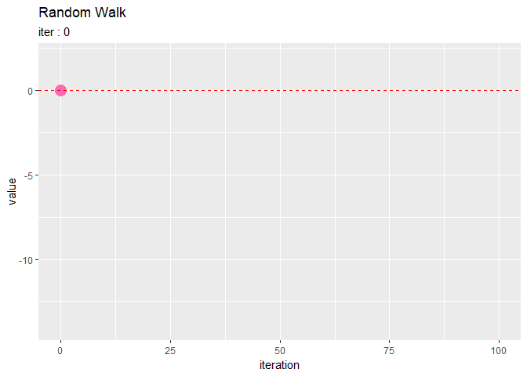

```r
# 1次元ランダムウォークを作図
anim <- ggplot(random_df, aes(x = iteration, y = value)) +
  geom_point(color = "hotpink", size = 5) + # 散布図
  geom_path(color = "hotpink", size = 1, alpha = 0.5) + # 折れ線
  geom_hline(yintercept = 0, color = "red", linetype = "dashed") + # 水平線
  gganimate::transition_reveal(along = iteration) + # フレーム
  labs(title = "Random Walk",
       subtitle = "iter : {frame_along}")

# gif画像を作成
gganimate::animate(plot = anim, nframes = max_iter+1, fps = 10)
```

目安として、期待値($y = 0$)の線を引いています。

### 複数サンプル

続いて、複数個のサンプルを同時に描画します。

`-1`か`1`をランダムに生成します。

```r
# 試行回数を指定
max_iter <- 100

# サンプルサイズを指定
sample_size <- 10

# ランダムに値を生成
random_vec <-  sample(x = c(-1, 1), size = max_iter*sample_size, replace = TRUE)
random_vec[1:10]
```

```
##  [1] -1  1  1 -1  1 -1 -1  1 -1 -1
```

試行回数`max_iter`とサンプルサイズ`sample_size`を指定して、`max_iter * sample_size`個の値を生成します。

生成した値をデータフレームに格納します。

```r
# 元になるデータフレームを確認
tibble::tibble(
  iteration = rep(0:max_iter, each = sample_size),
  id = rep(1:sample_size, times = max_iter+1),
  random_val = c(rep(0, sample_size), random_vec)
) %>%
  dplyr::filter(iteration == 1) %>% # 1回目の結果を表示
  head()
```

```
## # A tibble: 6 x 3
##   iteration    id random_val
##       <int> <int>      <dbl>
## 1         1     1         -1
## 2         1     2          1
## 3         1     3          1
## 4         1     4         -1
## 5         1     5          1
## 6         1     6         -1
```

全てのサンプルに対して0回目の結果に相当する行を加えます。  
また、`random_vec`の1番目の要素をサンプル1の1回目の結果、2番目の要素をサンプル2の1回目の結果と続けて、さらに`sample_size + 1`番目の要素をサンプル1の2回目の結果と続けて割り当てることにします。

`0`から`max_iter`までの整数をそれぞれ`sample_size`個に複製して、試行回数(`iteration`)列とします。  
`1`から`sample_size`までの整数を`max_iter + 1`回繰り返して、サンプル番号(`id`)列とします。  
`sample_size`個の`0`の後に`random_vec`を続けて、乱数(`random_val`)列とします。

サンプルごとに過去の値を合計します。

```r
# 試行ごとに集計
random_df <- tibble::tibble(
  iteration = rep(0:max_iter, each = sample_size),
  id = rep(1:sample_size, times = max_iter+1) %>%
    as.factor(),
  random_val = c(rep(0, sample_size), random_vec)
) %>%
  dplyr::group_by(id) %>% # サンプルごとにグループ化
  dplyr::mutate(value = cumsum(random_val)) %>% # 各試行までの合計
  dplyr::group_by() # グループ化の解除

# 3サンプルの3回目までの結果
random_df %>%
  dplyr::filter(iteration <= 3, id %in% 1:3)
```

```
## # A tibble: 12 x 4
##    iteration id    random_val value
##        <int> <fct>      <dbl> <dbl>
##  1         0 1              0     0
##  2         0 2              0     0
##  3         0 3              0     0
##  4         1 1             -1    -1
##  5         1 2              1     1
##  6         1 3              1     1
##  7         2 1             -1    -2
##  8         2 2              1     2
##  9         2 3              1     2
## 10         3 1             -1    -3
## 11         3 2              1     3
## 12         3 3             -1     1
```

作図用に、サンプル番号(`id`列の値)を因子型にしておきます。  
`id`列が同じ値でグループ化して、サンプルごとに`cumsum()`で累積和を計算します。

アニメーションを作成します。

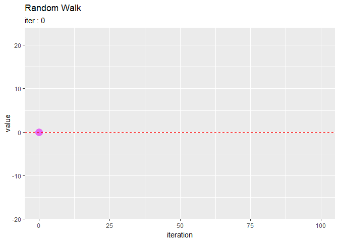

```r
# 2次元ランダムウォークを作図
anim <- ggplot(random_df, aes(x = iteration, y = value, color = id)) +
  geom_point(size = 5, show.legend = FALSE) + # 散布図
  geom_path(size = 1, alpha = 0.5, show.legend = FALSE) + # 折れ線
  geom_hline(yintercept = 0, color = "red", linetype = "dashed") + # 水平線
  gganimate::transition_reveal(along = iteration) + # フレーム
  labs(title = "Random Walk",
       subtitle = "iter : {frame_along}")

# gif画像を作成
gganimate::animate(plot = anim, nframes = max_iter+1, fps = 10)
```

`sample_size`個の折れ線グラフが描画されます。

最終結果は次のようになります。

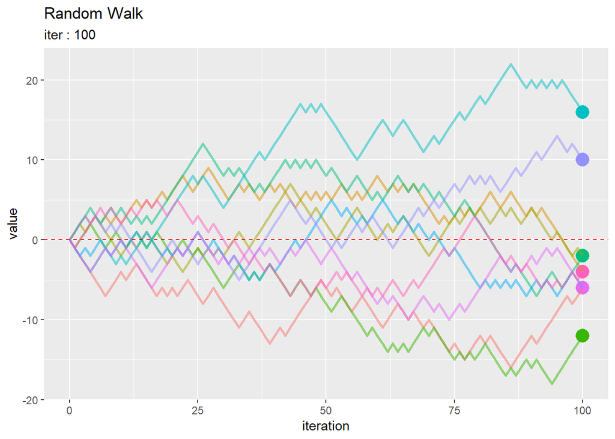

```r
# 最終結果
random_df %>%
  dplyr::filter(iteration == max_iter) %>%
  ggplot() +
  geom_point(mapping = aes(x = iteration, y = value, color = id),
             size = 5, show.legend = FALSE) + # 散布図
  geom_path(data = random_df, mapping = aes(x = iteration, y = value, color = id),
            size = 1, alpha = 0.5, show.legend = FALSE) + # 折れ線
  geom_hline(yintercept = 0, color = "red", linetype = "dashed") + # 水平線
  labs(title = "Random Walk",
       subtitle = paste0("iter : ", max_iter))
```

以上で、1次元ランダムウォークを作図できました。試行回数(時間)方向の変化も合わせて可視化しているので2次元に移動していますが、あくまで縦軸に対してランダムに移動しています。次は、x軸とy軸の2方向へ移動する場合を扱います。

## 2次元ランダムウォーク：2方向移動

x軸またはy軸方向に移動するランダムウォークをアニメーションで可視化します。

### 1サンプル

まずは、1個のサンプルを描画します。

移動する方向を示す値をランダムに生成します。

```r
# 試行回数を指定
max_iter <- 100

# ランダムに値を生成
random_val_vec <- sample(c(-1, 1), size = max_iter, replace = TRUE)

# ランダムに軸を生成
random_axis_vec <- sample(c("x", "y"), size = max_iter, replace = TRUE)

# 確認
random_val_vec[1:10]; random_axis_vec[1:10]
```

```
##  [1]  1  1 -1 -1 -1  1 -1  1  1 -1
```

```
##  [1] "y" "y" "x" "x" "y" "y" "x" "x" "x" "y"
```

正方向の移動(`1`)または負方向の移動(`-1`)をランダムに生成します。  
さらに、x軸方向の移動(`"x"`)またはy軸方向の移動(`"y"`)をランダムに生成します。

`1`と`y`の組み合わせが生成されれば、y軸を正の方向に移動します。

生成した値をデータフレームに格納します。

```r
# 元になるデータフレームを確認
tibble::tibble(
  iteration = c(0, 0, 1:max_iter),
  random_val = c(0, 0, random_val_vec),
  axis = c("x", "y", random_axis_vec)
) %>%
  head()
```

```
## # A tibble: 6 x 3
##   iteration random_val axis
##       <dbl>      <dbl> <chr>
## 1         0          0 x
## 2         0          0 y
## 3         1          1 y
## 4         2          1 y
## 5         3         -1 x
## 6         4         -1 x
```

0回目の結果(スタート地点・原点)に相当する行を加えておきます。

x軸・y軸の値ごとに過去の値の合計を求めます。

```r
# 試行ごとに集計
random_df <- tibble::tibble(
  iteration = c(0, 0, 1:max_iter),
  random_val = c(0, 0, random_val_vec),
  axis = c("x", "y", random_axis_vec)
) %>%
  tidyr::pivot_wider(
    names_from = axis,
    values_from = random_val,
    values_fill = 0
  ) %>% # 横型に変形
  dplyr::mutate(
    x = cumsum(x),
    y = cumsum(y)
  ) # 各試行までの合計
head(random_df)
```

```
## # A tibble: 6 x 3
##   iteration     x     y
##       <dbl> <dbl> <dbl>
## 1         0     0     0
## 2         1     0     1
## 3         2     0     2
## 4         3    -1     2
## 5         4    -2     2
## 6         5    -2     1
```

`pivot_wider()`で、`axis`列と`random_val`列を展開します。  
`names_from`引数に`axis`を指定します。`axis`列の値は`x`か`y`なので、`x`列と`y`列ができます。  
`values_from`引数に`random_val`を指定します。`x`列と`y`列の値は、`random_val`列の対応する値または欠損値`NA`になります。  
`values_fill`引数に`0`を指定すると、`NA`ではなく`0`になります。

簡単な例で試してみます。

```r
# 簡単な例で確認
tibble::tibble(
  iteration = c(1, 2),
  random_val = c(-1, 1),
  axis = c("y", "x")
) %>%
  tidyr::pivot_wider(
    names_from = axis,
    values_from = random_val
  )
```

```
## # A tibble: 2 x 3
##   iteration     y     x
##       <dbl> <dbl> <dbl>
## 1         1    -1    NA
## 2         2    NA     1
```

追加された`x`列と`y`列それぞれの累積和を`cumsum()`で計算します。

アニメーションを作成します。

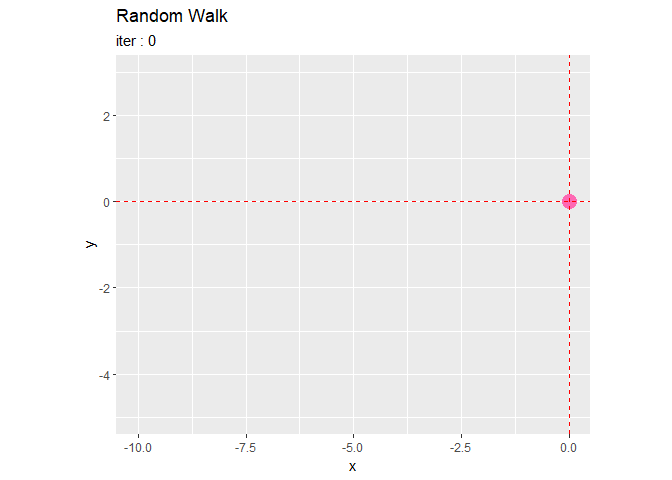

```r
# 2次元ランダムウォークを作図
anim <- ggplot(random_df, aes(x = x, y = y)) +
  geom_point(color = "hotpink", size = 5) + # 散布図
  geom_path(color = "hotpink", size = 1, alpha = 0.5) + # 折れ線
  geom_hline(yintercept = 0, color = "red", linetype = "dashed") + # 水平線
  geom_vline(xintercept = 0, color = "red", linetype = "dashed") + # 垂直線
  gganimate::transition_reveal(along = iteration) + # フレーム
  coord_fixed(ratio = 1) + # アスペクト比
  labs(title = "Random Walk",
       subtitle = "iter : {frame_along}")

# gif画像を作成
gganimate::animate(plot = anim, nframes = max_iter+1, fps = 10)
```

目安として、$x = 0$と$y = 0$の線を引いています。

### 複数サンプル

続いて、複数個のサンプルを同時に描画します。

移動する方向を示す値をランダムに生成します。

```r
# 試行回数を指定
max_iter <- 100

# サンプルサイズを指定
sample_size <- 10

# ランダムに値を生成
random_value_vec <- sample(x = c(-1, 1), size = max_iter*sample_size, replace = TRUE)

# ランダムに軸を生成
random_axis_vec <- sample(x = c("x", "y"), size = max_iter*sample_size, replace = TRUE)

# 確認
random_val_vec[1:10]; random_axis_vec[1:10]
```

```
##  [1]  1  1 -1 -1 -1  1 -1  1  1 -1
```

```
##  [1] "y" "y" "y" "x" "y" "x" "y" "y" "x" "x"
```

試行回数`max_iter`とサンプルサイズ`sample_size`を指定して、`max_iter * sample_size`個の値と軸を生成します。

生成した値をデータフレームに格納します。

```r
# 元になるデータフレームを確認
tidyr::tibble(
  iteration = rep(c(0, 0, 1:max_iter), each = sample_size),
  id = rep(1:sample_size, times = max_iter+2),
  random_val = c(rep(0, times = sample_size*2), random_value_vec),
  axis = c(rep(c("x", "y"), each = sample_size), random_axis_vec)
) %>%
  dplyr::filter(iteration == 1) %>% # 1回目の結果を表示
  head()
```

```
## # A tibble: 6 x 4
##   iteration    id random_val axis
##       <dbl> <int>      <dbl> <chr>
## 1         1     1          1 y
## 2         1     2          1 y
## 3         1     3         -1 y
## 4         1     4         -1 x
## 5         1     5         -1 y
## 6         1     6          1 x
```

全てのサンプルに対して0回目の結果に相当する行を加えます。  
また、`random_***_vec`の1番目の要素をサンプル1の1回目の結果、2番目の要素をサンプル2の1回目の結果と続けて、`sample_size + 1`番目の要素をサンプル1の2回目の結果と続けて割り当てることにします。

2つの`0`と`1`から`max_iter`までの整数をそれぞれ`sample_size`個に複製して、試行回数(`iteration`)列とします。  
`1`から`sample_size`までの整数を`max_iter + 2`回繰り返して、サンプル番号(`id`)列とします。  
`sample_size * 2`個の`0`の後に`random_value_vec`を続けて、乱数(`random_val`)列とします。  
`sample_size`個の`"x"`と`"y"`の後に`random_axis_vec`を続けて、軸(`axis`)列とします。

サンプルごとに過去の値を合計します。

```r
# 試行ごとに集計
random_df <- tidyr::tibble(
  iteration = rep(c(0, 0, 1:max_iter), each = sample_size),
  id = rep(1:sample_size, times = max_iter+2) %>%
    as.factor(),
  random_val = c(rep(0, times = sample_size*2), random_value_vec),
  axis = c(rep(c("x", "y"), each = sample_size), random_axis_vec)
) %>%
  tidyr::pivot_wider(
    names_from = axis,
    values_from = random_val,
    values_fill = 0
  ) %>% # 横型に変形
  dplyr::group_by(id) %>% # サンプルごとにグループ化
  dplyr::mutate(
    x = cumsum(x),
    y = cumsum(y)
  ) %>%  # 各試行までの合計
  dplyr::ungroup() # グループ化の解除

# 3サンプルの3回目までの結果
random_df %>%
  dplyr::filter(iteration <= 3, id %in% 1:3)
```

```
## # A tibble: 12 x 4
##    iteration id        x     y
##        <dbl> <fct> <dbl> <dbl>
##  1         0 1         0     0
##  2         0 2         0     0
##  3         0 3         0     0
##  4         1 1         0     1
##  5         1 2         0     1
##  6         1 3         0    -1
##  7         2 1         0     0
##  8         2 2         0     0
##  9         2 3         1    -1
## 10         3 1         0     1
## 11         3 2         1     0
## 12         3 3         2    -1
```

作図用に、サンプル番号(`id`列の値)を因子型にしておきます。  
`pivot_wider()`で、`axis`列と`random_val`列を展開します。  
`id`列が同じ値でグループ化して、サンプルごとに`cumsum()`で累積和を計算します。

アニメーションを作成します。

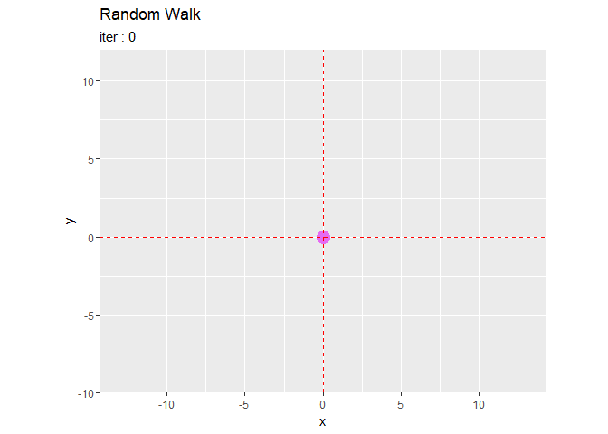

```r
# 2次元ランダムウォークを作図
anim <- ggplot(random_df, aes(x = x, y = y, color = id)) +
  geom_point(size = 5, show.legend = FALSE) + # 散布図
  geom_path(size = 1, alpha = 0.3, show.legend = FALSE) + # 折れ線
  geom_hline(yintercept = 0, color = "red", linetype = "dashed") + # 水平線
  geom_vline(xintercept = 0, color = "red", linetype = "dashed") + # 垂直線
  gganimate::transition_reveal(along = iteration) + # フレーム
  coord_fixed(ratio = 1) + # アスペクト比
  labs(title = "Random Walk",
       subtitle = "iter : {frame_along}")

# gif画像を作成
gganimate::animate(plot = anim, nframes = max_iter+1, fps = 10)
```

`sample_size`個の折れ線グラフが描画されます。

最終結果は次のようになります。

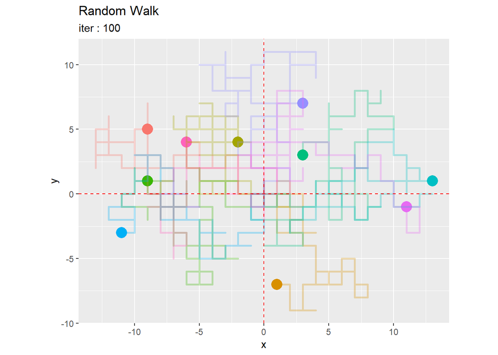

```r
# 最終結果
random_df %>%
  dplyr::filter(iteration == max_iter) %>%
  ggplot() +
  geom_point(mapping = aes(x = x, y = y, color = id),
             size = 5, show.legend = FALSE) + # 散布図
  geom_path(data = random_df, mapping = aes(x = x, y = y, color = id),
            size = 1, alpha = 0.3, show.legend = FALSE) + # 折れ線
  geom_hline(yintercept = 0, color = "red", linetype = "dashed") + # 水平線
  geom_vline(xintercept = 0, color = "red", linetype = "dashed") + # 垂直線
  coord_fixed(ratio = 1) + # アスペクト比
  labs(title = "Random Walk",
       subtitle = paste0("iter : ", max_iter))
```

以上で、2次元ランダムウォークを作図できました。この例では、x軸またはy軸に対して並行に移動しました。次は、平面上の全ての方向に移動する場合を扱います。

## 2次元ランダムウォーク：全方向移動

平面上を移動するランダムウォークをアニメーションで可視化します。

### 全方向移動の確認

まずは、平面上をランダムに移動する処理を確認します。

単位円上の点を作成します。

```r
# フレーム数を指定
N <- 101

# 単位円上の点を作成
df <- tibble::tibble(
  n = 1:N, # 時計回りならN:1
  d = seq(from = 0, to = 1, length.out = N),
  r = 2 * pi * d,
  x = cos(r),
  y = sin(r)
)
head(df)
```

```
## # A tibble: 6 x 5
##       n     d      r     x      y
##   <int> <dbl>  <dbl> <dbl>  <dbl>
## 1     1  0    0      1     0
## 2     2  0.01 0.0628 0.998 0.0628
## 3     3  0.02 0.126  0.992 0.125
## 4     4  0.03 0.188  0.982 0.187
## 5     5  0.04 0.251  0.969 0.249
## 6     6  0.05 0.314  0.951 0.309
```

0から1の値$d$を作成します。  
さらに、円周率$\pi$を使って$r = 2 \pi d$とします。$r$は、0から$2 \pi$の値になります。  
x軸の値を$x = \cos r$、y軸の値を$y = \sin r$で計算します。

作成した点を描画します。

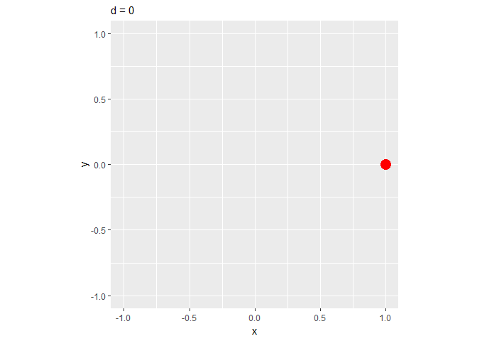

```r
# 単位円上の点を作図
anim <- ggplot(df, aes(x = x, y = y)) +
  geom_point(color = "red", size = 5) + # 散布図
  geom_path(color = "hotpink") + # 折れ線
  gganimate::transition_reveal(d) + # フレーム
  coord_fixed(ratio = 1) + # アスペクト比
  labs(subtitle = "d = {frame_along}")

# gif画像を作成
gganimate::animate(plot = anim, nframes = N, fps = 10)
```

$0 \leq d < 1$の($0 \leq r < 2 \pi$の)の点が、原点から半径1の円上の点になるのが分かります。

作成した点と原点を繋ぐ線を描画します。

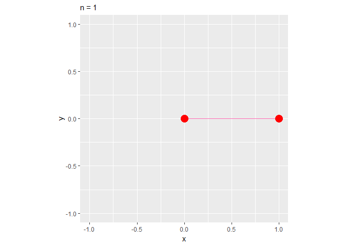

```r
# 原点から単位円上の点の方向を作図
anim <- df %>%
  rbind(tibble::tibble(n = 1:N, d = NA, r = NA, x = 0, y = 0)) %>% # 原点を追加
  ggplot(aes(x = x, y = y)) +
  geom_line(color = "hotpink") + # 折れ線グラフ
  geom_point(color = "red", fill = "red", size = 5) + # 散布図
  gganimate::transition_manual(n) + # フレーム
  coord_fixed(ratio = 1) + # アスペクト比
  labs(subtitle = "n = {current_frame}")

# gif画像を作成
gganimate::animate(plot = anim, nframes = N, fps = 10)
```

作成した点$(x, y)$は、原点$(0, 0)$からx軸方向に$x$・y軸方向に$y$移動(加算)した点であり、また直線距離で1移動した点と言えます。  
つまり、$d$を0から1の($r$を0から$2 \pi$の)乱数として生成すると、現在の点(位置)からランダムな方向に距離1だけ移動できます。

### 1サンプル

1個のサンプルを描画します。

0から$2 \pi$の一様乱数を生成します。

```r
# 試行回数を指定
max_iter <- 100

# ランダムに値を生成
random_vec <- 2 * pi * runif(n = max_iter, min = 0, max = 1)
random_vec[1:5]
```

```
## [1] 5.8657922 0.5963878 0.5590333 2.7753207 4.6575379
```

一様乱数は、`runif()`で生成できます。最小値の引数`min`に`0`、最大値の引数`max`に`1`を指定します。(本当は0以上1未満の乱数を生成しないといけないのですが、やり方が分かりませんでした。)  
生成した`0`から`1`の乱数に、`2 * pi`を掛けます。`max`引数に`2 * pi`を指定してもできますが、ここでは原理的な部分が分かりやすいように処理しています。

生成した値からx軸とy軸の値を計算してデータフレームに格納して、過去の値の合計を求めます。

```r
# 試行ごとに集計
random_df <- tibble::tibble(
  iteration = 0:max_iter,
  x = c(0, cos(random_vec)),
  y = c(0, sin(random_vec))
) %>%
  dplyr::mutate(
    x = cumsum(x),
    y = cumsum(y)
  ) # 各試行までの合計
head(random_df)
```

```
## # A tibble: 6 x 3
##   iteration     x       y
##       <int> <dbl>   <dbl>
## 1         0 0      0
## 2         1 0.914 -0.405
## 3         2 1.74   0.156
## 4         3 2.59   0.687
## 5         4 1.66   1.04
## 6         5 1.60   0.0463
```

0回目の結果(スタート地点・原点)に相当する行を加えておきます。  
`x`列と`y`列それぞれの累積和を`cumsum()`で計算します。

アニメーションを作成します。

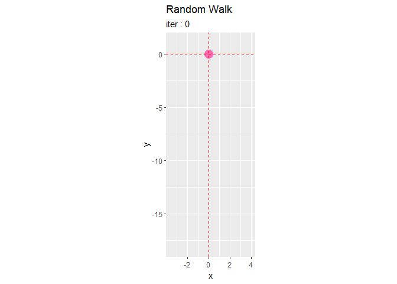

```r
# 2次元ランダムウォークを作図
anim <- ggplot(random_df, aes(x = x, y = y)) +
  geom_point(color = "hotpink", size = 5) + # 散布図
  geom_path(color = "hotpink", size = 1, alpha = 0.5) + # 折れ線
  geom_hline(yintercept = 0, color = "red", linetype = "dashed") + # 水平線
  geom_vline(xintercept = 0, color = "red", linetype = "dashed") + # 垂直線
  gganimate::transition_reveal(along = iteration) + # フレーム
  coord_fixed(ratio = 1) + # アスペクト比
  labs(title = "Random Walk",
       subtitle = "iter : {frame_along}")

# gif画像を作成
gganimate::animate(plot = anim, nframes = max_iter+1, fps = 10)
```

目安として、$x = 0$と$y = 0$の線を引いています。

### 複数サンプル

続いて、複数個のサンプルを同時に描画します。

0から$2 \pi$の一様乱数を生成します。

```r
# 試行回数を指定
max_iter <- 100

# サンプルサイズを指定
sample_size <- 10

# ランダムに値を生成
random_vec <- 2 * pi * runif(n = max_iter*sample_size, min = 0, max = 1)
random_vec[1:5]
```

```
## [1] 2.496610 2.428737 5.144837 2.899578 5.663809
```

試行回数`max_iter`とサンプルサイズ`sample_size`を指定して、`max_iter * sample_size`個の値を生成します。

生成した値をデータフレームに格納します。

```r
# 元になるデータフレームを確認
tibble::tibble(
  iteration = rep(0:max_iter, each = sample_size),
  id = rep(1:sample_size, times = max_iter+1),
  x = c(rep(0, times = sample_size), cos(random_vec)),
  y = c(rep(0, times = sample_size), sin(random_vec))
) %>%
  dplyr::filter(iteration == 1) %>% # 1回目の結果を表示
  head()
```

```
## # A tibble: 6 x 4
##   iteration    id      x      y
##       <int> <int>  <dbl>  <dbl>
## 1         1     1 -0.799  0.601
## 2         1     2 -0.756  0.654
## 3         1     3  0.419 -0.908
## 4         1     4 -0.971  0.240
## 5         1     5  0.814 -0.581
## 6         1     6  0.812  0.584
```

全てのサンプルに対して0回目の結果に相当する行を加えます。  
また、`random_vec`の1番目の要素をサンプル1の1回目の結果、2番目の要素をサンプル2の1回目の結果と続けて、さらに`sample_size + 1`番目の要素をサンプル1の2回目の結果と続けて割り当てることにします。

`0`から`max_iter`までの整数をそれぞれ`sample_size`個に複製して、試行回数(`iteration`)列とします。  
`1`から`sample_size`までの整数を`max_iter + 1`回繰り返して、サンプル番号(`id`)列とします。  
`sample_size`個の`0`の後に`cos(random_vec), sin(random_vec)`を続けて、x軸y軸(`x, y`)列とします。

サンプルごとに過去の値を合計を求めます。

```r
# 試行ごとに集計
random_df <- tibble::tibble(
  iteration = rep(0:max_iter, each = sample_size),
  id = rep(1:sample_size, times = max_iter+1) %>%
    as.factor(),
  x = c(rep(0, times = sample_size), cos(random_vec)),
  y = c(rep(0, times = sample_size), sin(random_vec))
) %>%
  dplyr::group_by(id) %>% # サンプルごとにグループ化
  dplyr::mutate(
    x = cumsum(x),
    y = cumsum(y)
  ) %>% # 各試行までの合計
  dplyr::ungroup() # グループ化の解除

# 3サンプルの3回目までの結果
random_df %>%
  dplyr::filter(iteration <= 3, id %in% 1:3)
```

```
## # A tibble: 12 x 4
##    iteration id         x      y
##        <int> <fct>  <dbl>  <dbl>
##  1         0 1      0      0
##  2         0 2      0      0
##  3         0 3      0      0
##  4         1 1     -0.799  0.601
##  5         1 2     -0.756  0.654
##  6         1 3      0.419 -0.908
##  7         2 1     -0.100 -0.114
##  8         2 2     -1.14   1.58
##  9         2 3     -0.120 -1.75
## 10         3 1      0.858 -0.400
## 11         3 2     -2.14   1.63
## 12         3 3     -0.436 -2.70
```

作図用に、サンプル番号(`id`列の値)を因子型にしておきます。  
サンプル番号(`id`列)でグループ化して、x軸の値(`x`列)とy軸の値(`y`列)をそれぞれ`cumsum()`で累積和を計算します。

アニメーションを作成します。

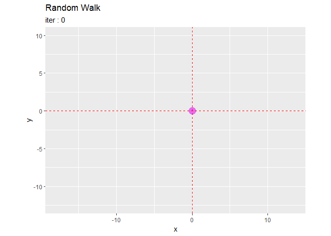

```r
# 2次元ランダムウォークを作図
anim <- ggplot(random_df, aes(x = x, y = y, color = id)) +
  geom_point(size = 5, show.legend = FALSE) + # 散布図
  geom_path(size = 1, alpha = 0.3, show.legend = FALSE) + # 折れ線
  geom_hline(yintercept = 0, color = "red", linetype = "dashed") + # 水平線
  geom_vline(xintercept = 0, color = "red", linetype = "dashed") + # 垂直線
  gganimate::transition_reveal(along = iteration) + # フレーム
  coord_fixed(ratio = 1) + # アスペクト比
  labs(title = "Random Walk",
       subtitle = "iter : {frame_along}")

# gif画像を作成
gganimate::animate(plot = anim, nframes = max_iter+1, fps = 10)
```

`sample_size`個の折れ線グラフが描画されます。

最終結果は次のようになります。

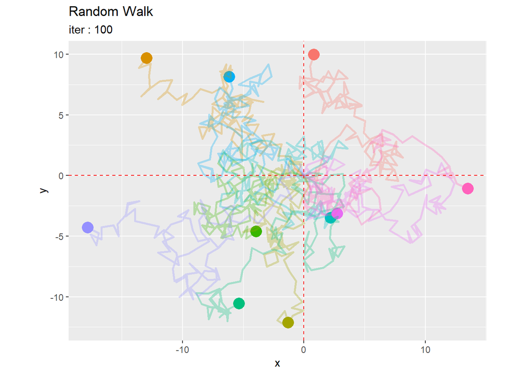

```r
# 最終結果
random_df %>%
  dplyr::filter(iteration == max_iter) %>%
  ggplot() +
  geom_point(mapping = aes(x = x, y = y, color = id),
             size = 5, show.legend = FALSE) + # 散布図
  geom_path(data = random_df, mapping = aes(x = x, y = y, color = id),
            size = 1, alpha = 0.3, show.legend = FALSE) + # 折れ線
  geom_hline(yintercept = 0, color = "red", linetype = "dashed") + # 水平線
  geom_vline(xintercept = 0, color = "red", linetype = "dashed") + # 垂直線
  coord_fixed(ratio = 1) + # アスペクト比
  labs(title = "Random Walk",
       subtitle = paste0("iter : ", max_iter))
```

以上で、2次元ランダムウォークを作図できました。